# Predicting Student Performance with Multiple Linear Regression

IA Oscar

Input data set using read.csv()

```r
df <- read.csv("/Users/oscarescobar/Desktop/Student_Performance.csv", header = TRUE)
```

To find your file path make sure the csv file is located on your desktop for easy access. Then, right click the file and select “Get Info” (Mac Users) or “Properties” (Windows Users) Lastly, the path file will be located next to “Where” (Mac Users) or “Location” (Windows Users)

The general format for a file path for a file that is on your desktop is: “/Users/username/Desktop/filename.csv” for Mac Users “C:/Users/username/Desktop/filename.csv” for Windows Users

Use str() to get info on the data

```r
str(df)
```

```
## 'data.frame':    10001 obs. of  6 variables:
##  $ Hours.Studied                   : int  7 4 8 5 7 3 7 8 5 4 ...
##  $ Previous.Scores                 : int  99 82 51 52 75 78 73 45 77 89 ...
##  $ Extracurricular.Activities      : chr  "Yes" "No" "Yes" "Yes" ...
##  $ Sleep.Hours                     : int  9 4 7 5 8 9 5 4 8 4 ...
##  $ Sample.Question.Papers.Practiced: int  1 2 2 2 5 6 6 6 2 0 ...
##  $ Performance.Index               : int  91 65 45 36 66 61 63 42 61 69 ...
```

Lets clean this data set!

When cleaning data we have to consider many potential defects with our data, the issues you encounter may depend on the context of the data itself: 1. Missing values 2. Duplicates 3. Invalid data

How many missing values does this data set have?

```r
sum(is.na(df))
```

```
## [1] 2
```

Where are the missing values?

```r
colSums(is.na(df))
```

```
##                    Hours.Studied                  Previous.Scores
##                                0                                0
##       Extracurricular.Activities                      Sleep.Hours
##                                0                                1
## Sample.Question.Papers.Practiced                Performance.Index
##                                0                                1
```

Use na.omit() to remove rows with missing data

```r
noMissingValues_df <- na.omit(df)

nrow(noMissingValues_df)
```

```
## [1] 9999
```

Question: Data is valuable and expensive, what are some workarounds if we didn’t want to delete this data?

How many duplicates?

```r
dupeSum <- sum(duplicated(noMissingValues_df))
dupeSum
```

```
## [1] 128
```

Remove duplicates

```r
noDupes_df <- unique(noMissingValues_df)

rowCount <- nrow(noDupes_df)
rowCount
```

```
## [1] 9871
```

Binary encoding: turn “Yes” & “No” into 1 & 0 so our model can function properly.

```r
binaryEncoded_df <-noDupes_df
binaryEncoded_df$Extracurricular.Activities <- ifelse(binaryEncoded_df$Extracurricular.Activities == "Yes", 1, 0)

clean_df <- binaryEncoded_df
print(head(clean_df))
```

```
##   Hours.Studied Previous.Scores Extracurricular.Activities Sleep.Hours
## 1             7              99                          1           9
## 2             4              82                          0           4
## 3             8              51                          1           7
## 4             5              52                          1           5
## 5             7              75                          0           8
## 6             3              78                          0           9
##   Sample.Question.Papers.Practiced Performance.Index
## 1                                1                91
## 2                                2                65
## 3                                2                45
## 4                                2                36
## 5                                5                66
## 6                                6                61
```

Remove target variable for multicollinearity analysis: To put it simply, multicollinearity is a problem caused when two or more predictor variables in your model have a high correlation. Correlation between predictors is bad, but correlation from predictor to target is great!

```r
variable_df<- clean_df[, !names(clean_df) %in% 'Performance.Index']
print(head(variable_df))
```

```
##   Hours.Studied Previous.Scores Extracurricular.Activities Sleep.Hours
## 1             7              99                          1           9
## 2             4              82                          0           4
## 3             8              51                          1           7
## 4             5              52                          1           5
## 5             7              75                          0           8
## 6             3              78                          0           9
##   Sample.Question.Papers.Practiced
## 1                                1
## 2                                2
## 3                                2
## 4                                2
## 5                                5
## 6                                6
```

Create correlation matrix: correlation values range from -1 to 1. A number closer to 1 or -1 indicates high correlation, while a number closer to 0 indicates low correlation. The diagonal of 1’s is to be expected as a variable is perfectly correleted with itself.

```r
corrmat <- cor(variable_df)
print(corrmat)
```

```
##                                  Hours.Studied Previous.Scores
## Hours.Studied                      1.000000000    -0.010377501
## Previous.Scores                   -0.010377501     1.000000000
## Extracurricular.Activities         0.004939865     0.009449928
## Sleep.Hours                        0.002443523     0.007753067
## Sample.Question.Papers.Practiced   0.015628154     0.008837299
##                                  Extracurricular.Activities  Sleep.Hours
## Hours.Studied                                   0.004939865  0.002443523
## Previous.Scores                                 0.009449928  0.007753067
## Extracurricular.Activities                      1.000000000 -0.023958807
## Sleep.Hours                                    -0.023958807  1.000000000
## Sample.Question.Papers.Practiced                0.013940184  0.004963854
##                                  Sample.Question.Papers.Practiced
## Hours.Studied                                         0.015628154
## Previous.Scores                                       0.008837299
## Extracurricular.Activities                            0.013940184
## Sleep.Hours                                           0.004963854
## Sample.Question.Papers.Practiced                      1.000000000
```

Correlation Heatmap: since the above matrix is difficult to read, we can visualize it by creating a heatmap.

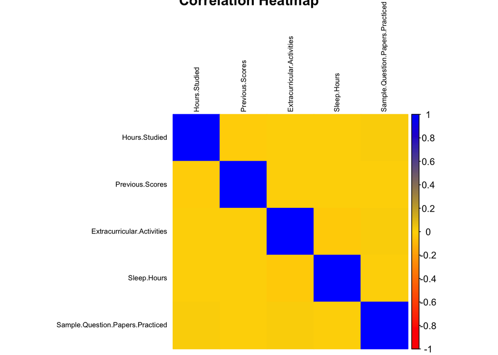

```r
#install.packages("corrplot")
library(corrplot)
corrplot(corrmat, method = "color", type = "full",
         col = colorRampPalette(c("red", "gold", "blue"))(200),
         tl.cex = 0.6, tl.col = "black", title = "Correlation Heatmap")
```

80-20 Data Split: We must split our data in order to train it on the 80% and test it on the 20%. This is a very common split used in data science.

```r
nrows <- nrow(clean_df)
trainsize <- round(0.8*nrows)
trainindex <- sample(1:nrows, trainsize, replace = FALSE)

train_df <- clean_df[trainindex, ]
test_df <- clean_df[-trainindex, ]
```

Build model

```r
train_model <- lm(train_df$Performance.Index ~ train_df$Hours.Studied + train_df$Previous.Scores + train_df$Extracurricular.Activities + train_df$Sleep.Hours + train_df$Sample.Question.Papers.Practiced, data = train_df)

summary(train_model)
```

```
##
## Call:
## lm(formula = train_df$Performance.Index ~ train_df$Hours.Studied +
##     train_df$Previous.Scores + train_df$Extracurricular.Activities +
##     train_df$Sleep.Hours + train_df$Sample.Question.Papers.Practiced,
##     data = train_df)
##
## Residuals:
##     Min      1Q  Median      3Q     Max
## -7.5827 -1.3718 -0.0256  1.3687  8.7972
##
## Coefficients:
##                                             Estimate Std. Error t value
## (Intercept)                               -34.139869   0.144261 -236.65
## train_df$Hours.Studied                      2.853453   0.008889  321.03
## train_df$Previous.Scores                    1.019232   0.001327  768.02
## train_df$Extracurricular.Activities         0.586482   0.046157   12.71
## train_df$Sleep.Hours                        0.480507   0.013601   35.33
## train_df$Sample.Question.Papers.Practiced   0.198495   0.008037   24.70
##                                           Pr(>|t|)
## (Intercept)                                 <2e-16 ***
## train_df$Hours.Studied                      <2e-16 ***
## train_df$Previous.Scores                    <2e-16 ***
## train_df$Extracurricular.Activities         <2e-16 ***
## train_df$Sleep.Hours                        <2e-16 ***
## train_df$Sample.Question.Papers.Practiced   <2e-16 ***
## ---
## Signif. codes:  0 '***' 0.001 '**' 0.01 '*' 0.05 '.' 0.1 ' ' 1
##
## Residual standard error: 2.049 on 7891 degrees of freedom
## Multiple R-squared:  0.9887, Adjusted R-squared:  0.9887
## F-statistic: 1.377e+05 on 5 and 7891 DF,  p-value: < 2.2e-16
```

Variance Inflation Factors (VIF): VIFs are values that measure collinearity. We want these values as close to 1 as possible.

```r
#install.packages("car")
library(car)
vif(train_model)
```

```
##                    train_df$Hours.Studied
##                                  1.000516
##                  train_df$Previous.Scores
##                                  1.000587
##       train_df$Extracurricular.Activities
##                                  1.001442
##                      train_df$Sleep.Hours
##                                  1.000875
## train_df$Sample.Question.Papers.Practiced
##                                  1.000564
```

Step() iteratively includes or removes each variable from the model to tell you if it is worth including each variable or not. The best model will have the lowest RSS (Residual Sum of Squares) and AIC (Akaike Information Criterion).

```r
forward_model <- step(train_model, direction = "forward")
```

```
## Start:  AIC=11338.35
## train_df$Performance.Index ~ train_df$Hours.Studied + train_df$Previous.Scores +
##     train_df$Extracurricular.Activities + train_df$Sleep.Hours +
##     train_df$Sample.Question.Papers.Practiced
```

```r
summary(forward_model)
```

```
##
## Call:
## lm(formula = train_df$Performance.Index ~ train_df$Hours.Studied +
##     train_df$Previous.Scores + train_df$Extracurricular.Activities +
##     train_df$Sleep.Hours + train_df$Sample.Question.Papers.Practiced,
##     data = train_df)
##
## Residuals:
##     Min      1Q  Median      3Q     Max
## -7.5827 -1.3718 -0.0256  1.3687  8.7972
##
## Coefficients:
##                                             Estimate Std. Error t value
## (Intercept)                               -34.139869   0.144261 -236.65
## train_df$Hours.Studied                      2.853453   0.008889  321.03
## train_df$Previous.Scores                    1.019232   0.001327  768.02
## train_df$Extracurricular.Activities         0.586482   0.046157   12.71
## train_df$Sleep.Hours                        0.480507   0.013601   35.33
## train_df$Sample.Question.Papers.Practiced   0.198495   0.008037   24.70
##                                           Pr(>|t|)
## (Intercept)                                 <2e-16 ***
## train_df$Hours.Studied                      <2e-16 ***
## train_df$Previous.Scores                    <2e-16 ***
## train_df$Extracurricular.Activities         <2e-16 ***
## train_df$Sleep.Hours                        <2e-16 ***
## train_df$Sample.Question.Papers.Practiced   <2e-16 ***
## ---
## Signif. codes:  0 '***' 0.001 '**' 0.01 '*' 0.05 '.' 0.1 ' ' 1
##
## Residual standard error: 2.049 on 7891 degrees of freedom
## Multiple R-squared:  0.9887, Adjusted R-squared:  0.9887
## F-statistic: 1.377e+05 on 5 and 7891 DF,  p-value: < 2.2e-16
```

```r
stepwise_model <- step(train_model, direction = "both")
```

```
## Start:  AIC=11338.35
## train_df$Performance.Index ~ train_df$Hours.Studied + train_df$Previous.Scores +
##     train_df$Extracurricular.Activities + train_df$Sleep.Hours +
##     train_df$Sample.Question.Papers.Practiced
##
##                                             Df Sum of Sq     RSS   AIC
## <none>                                                     33140 11338
## - train_df$Extracurricular.Activities        1       678   33818 11496
## - train_df$Sample.Question.Papers.Practiced  1      2562   35702 11924
## - train_df$Sleep.Hours                       1      5242   38382 12496
## - train_df$Hours.Studied                     1    432816  465956 32211
## - train_df$Previous.Scores                   1   2477215 2510355 45510
```

```r
summary(stepwise_model)
```

```
##
## Call:
## lm(formula = train_df$Performance.Index ~ train_df$Hours.Studied +
##     train_df$Previous.Scores + train_df$Extracurricular.Activities +
##     train_df$Sleep.Hours + train_df$Sample.Question.Papers.Practiced,
##     data = train_df)
##
## Residuals:
##     Min      1Q  Median      3Q     Max
## -7.5827 -1.3718 -0.0256  1.3687  8.7972
##
## Coefficients:
##                                             Estimate Std. Error t value
## (Intercept)                               -34.139869   0.144261 -236.65
## train_df$Hours.Studied                      2.853453   0.008889  321.03
## train_df$Previous.Scores                    1.019232   0.001327  768.02
## train_df$Extracurricular.Activities         0.586482   0.046157   12.71
## train_df$Sleep.Hours                        0.480507   0.013601   35.33
## train_df$Sample.Question.Papers.Practiced   0.198495   0.008037   24.70
##                                           Pr(>|t|)
## (Intercept)                                 <2e-16 ***
## train_df$Hours.Studied                      <2e-16 ***
## train_df$Previous.Scores                    <2e-16 ***
## train_df$Extracurricular.Activities         <2e-16 ***
## train_df$Sleep.Hours                        <2e-16 ***
## train_df$Sample.Question.Papers.Practiced   <2e-16 ***
## ---
## Signif. codes:  0 '***' 0.001 '**' 0.01 '*' 0.05 '.' 0.1 ' ' 1
##
## Residual standard error: 2.049 on 7891 degrees of freedom
## Multiple R-squared:  0.9887, Adjusted R-squared:  0.9887
## F-statistic: 1.377e+05 on 5 and 7891 DF,  p-value: < 2.2e-16
```

```r
backward_model <- step(train_model, direction = "both")
```

```
## Start:  AIC=11338.35
## train_df$Performance.Index ~ train_df$Hours.Studied + train_df$Previous.Scores +
##     train_df$Extracurricular.Activities + train_df$Sleep.Hours +
##     train_df$Sample.Question.Papers.Practiced
##
##                                             Df Sum of Sq     RSS   AIC
## <none>                                                     33140 11338
## - train_df$Extracurricular.Activities        1       678   33818 11496
## - train_df$Sample.Question.Papers.Practiced  1      2562   35702 11924
## - train_df$Sleep.Hours                       1      5242   38382 12496
## - train_df$Hours.Studied                     1    432816  465956 32211
## - train_df$Previous.Scores                   1   2477215 2510355 45510
```

```r
summary(backward_model)
```

```
##
## Call:
## lm(formula = train_df$Performance.Index ~ train_df$Hours.Studied +
##     train_df$Previous.Scores + train_df$Extracurricular.Activities +
##     train_df$Sleep.Hours + train_df$Sample.Question.Papers.Practiced,
##     data = train_df)
##
## Residuals:
##     Min      1Q  Median      3Q     Max
## -7.5827 -1.3718 -0.0256  1.3687  8.7972
##
## Coefficients:
##                                             Estimate Std. Error t value
## (Intercept)                               -34.139869   0.144261 -236.65
## train_df$Hours.Studied                      2.853453   0.008889  321.03
## train_df$Previous.Scores                    1.019232   0.001327  768.02
## train_df$Extracurricular.Activities         0.586482   0.046157   12.71
## train_df$Sleep.Hours                        0.480507   0.013601   35.33
## train_df$Sample.Question.Papers.Practiced   0.198495   0.008037   24.70
##                                           Pr(>|t|)
## (Intercept)                                 <2e-16 ***
## train_df$Hours.Studied                      <2e-16 ***
## train_df$Previous.Scores                    <2e-16 ***
## train_df$Extracurricular.Activities         <2e-16 ***
## train_df$Sleep.Hours                        <2e-16 ***
## train_df$Sample.Question.Papers.Practiced   <2e-16 ***
## ---
## Signif. codes:  0 '***' 0.001 '**' 0.01 '*' 0.05 '.' 0.1 ' ' 1
##
## Residual standard error: 2.049 on 7891 degrees of freedom
## Multiple R-squared:  0.9887, Adjusted R-squared:  0.9887
## F-statistic: 1.377e+05 on 5 and 7891 DF,  p-value: < 2.2e-16
```

Model analysis: Residuals vs. Fitted should look like random scatter centered around 0. Q-Q Residuals should fall along the diagonal line to indicate a normal distribution of residuals. Scale-Location should look like random scatter around a straight line indicating similar variance in residuals. Residuals vs. Leverage should look like a random scatter around a line.

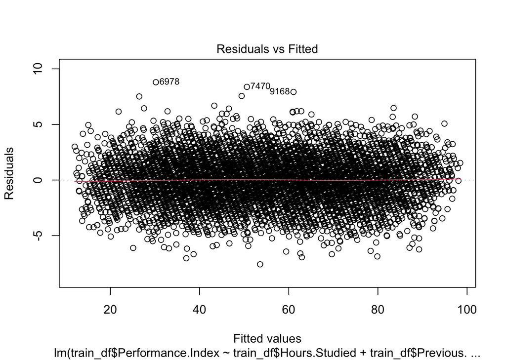

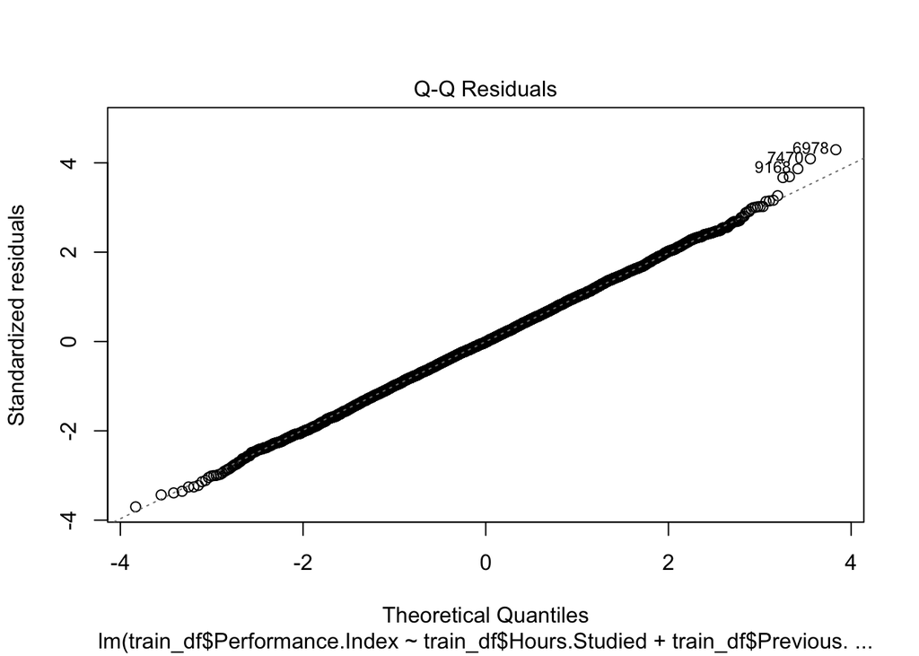

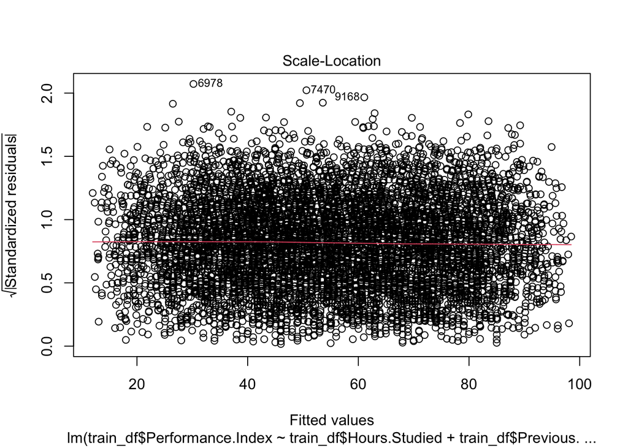

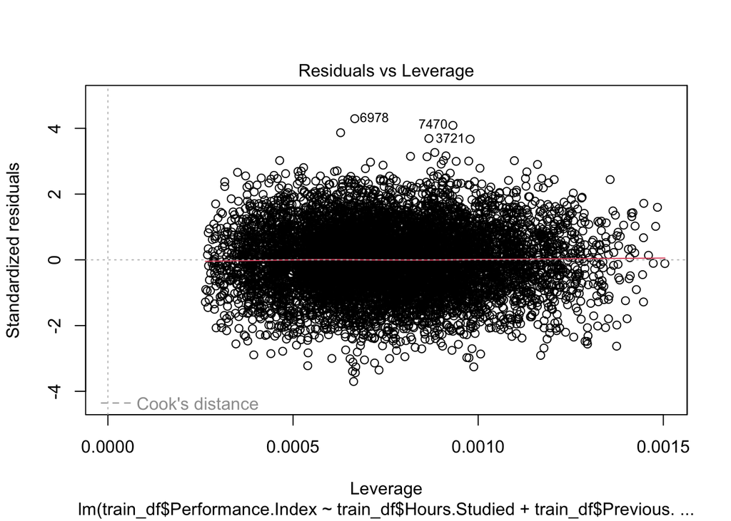

```r
plot(train_model)
```

Lets put our model to use by making predictions! First lets fit the model to the test data set part of the 20% split.

```r
perIndex <- test_df$Performance.Index
hours <- test_df$Hours.Studied
scores <- test_df$Previous.Score
extra <- test_df$Extracurricular.Activities
sleep <- test_df$Sleep.Hours
practice <- test_df$Sample.Question.Papers.Practiced
test_model <- lm(perIndex ~ hours + scores + extra + sleep + practice, data = test_df)
```

```r
summary(test_model)
```

```
##
## Call:
## lm(formula = perIndex ~ hours + scores + extra + sleep + practice,
##     data = test_df)
##
## Residuals:
##     Min      1Q  Median      3Q     Max
## -8.5360 -1.3454 -0.0341  1.3482  7.0886
##
## Coefficients:
##               Estimate Std. Error  t value Pr(>|t|)
## (Intercept) -33.816086   0.278983 -121.212  < 2e-16 ***
## hours         2.848300   0.017783  160.166  < 2e-16 ***
## scores        1.015012   0.002667  380.591  < 2e-16 ***
## extra         0.729888   0.091069    8.015 1.87e-15 ***
## sleep         0.482078   0.026760   18.015  < 2e-16 ***
## practice      0.176661   0.015979   11.056  < 2e-16 ***
## ---
## Signif. codes:  0 '***' 0.001 '**' 0.01 '*' 0.05 '.' 0.1 ' ' 1
##
## Residual standard error: 2.022 on 1968 degrees of freedom
## Multiple R-squared:  0.9888, Adjusted R-squared:  0.9888
## F-statistic: 3.472e+04 on 5 and 1968 DF,  p-value: < 2.2e-16
```

Predict values

```r
pred_df<- test_df[, !names(test_df) %in% 'Performance.Index']
predictions <- predict(test_model, data= pred_df)
print(head(predictions))
```

```
##        2        4        5        8       11       14
## 63.08970 36.69962 66.98781 38.36400 84.14799 33.26090
```

Create data frame to show our predictions with their corresponding actual values.

```r
results_df <- data.frame(Actual= perIndex, Predicted =predictions)
print(head(results_df))
```

```
##    Actual Predicted
## 2      65  63.08970
## 4      36  36.69962
## 5      66  66.98781
## 8      42  38.36400
## 11     84  84.14799
## 14     33  33.26090
```

Individual prediction of a student:

```r
singleStudent<- data.frame(hours=10, scores=79, extra=1, sleep=6, practice=2)
print(singleStudent)
```

```
##   hours scores extra sleep practice
## 1    10     79     1     6        2
```

```r
predicted_value <- predict(test_model, newdata= singleStudent)
print(predicted_value)
```

```
##        1
## 78.82851
```

Accuracy Check

Calculate Root Mean Squared Error which is a value that tells us the average amount of deviation from true values. We use this to compare performance across different models. This value is sensitive to larger differences, so we still encounter differences greater than the resulting RMSE.

```r
mse <- sqrt(mean((perIndex - predictions)^2))

print(mse)
```

```
## [1] 2.018669
```

Average difference between Predicted vs. Actual

```r
absDiff <- abs(results_df$Actual-results_df$Predicted)
meanDiff <- sum(absDiff)/length(absDiff)
print(meanDiff)
```

```
## [1] 1.595516
```

Check for values within certain ranges

```r
withinX <- ifelse(absDiff < 3, 1, 0)
print(sum(withinX)/length(withinX))
```

```
## [1] 0.8657548
```

Check for values within certain percentages

```r
accuracyWithinX <- ifelse(abs(results_df$Predicted-results_df$Actual) < 0.10*results_df$Actual,1,0)
print(sum(accuracyWithinX/length(accuracyWithinX)))
```

```
## [1] 0.9533941
```